# BigQuery & SQL

```python
import pandas as pd
import matplotlib.pyplot as plt
from google.cloud import bigquery
from sqlite3 import connect

# to get the zip file from my drive
from google.colab import drive
drive.mount('/content/drive')

# for plot size
plt.rcParams['figure.figsize'] = (14,7)
```

```python
#!pip install google-cloud-bigquery pandas
```

```python
import os
os.environ["GCLOUD_PROJECT"] = "dm-mt1" # work env
```

```python
!gcloud auth application-default login # authentication
```

```python
# 1a)
# Construct a BigQuery client m|m|mm
client = bigquery.Client()
```

```python
# 1b)
# query 2000 rows
query = """
      SELECT *
      FROM `bigquery-public-data.new_york.311_service_requests`
      LIMIT 2000
"""

# function for the API request
def get_results(query):
  query_job = client.query(query)
  return query_job.result()

# our output var using the function
output = get_results(query)

# extract first row
all_rows = [list(row) for row in output]
first_row = all_rows[0]
first_row
```

```
[31013228,
 datetime.datetime(2015, 7, 6, 12, 45, tzinfo=datetime.timezone.utc),
 datetime.datetime(2015, 7, 7, 15, 7, tzinfo=datetime.timezone.utc),
 'DEP',
 'Department of Environmental Protection',
 'ATF',
 None,
 None,
 None,
 None,
 None,
 'KINGS HWY',
 'FOSTER AVE',
 'KINGS HWY',
 'FOSTER AVE',
 'INTERSECTION',
 None,
 None,
 None,
 'Closed',
 None,
 None,
 datetime.datetime(2015, 7, 7, 15, 7, tzinfo=datetime.timezone.utc),
 'Unspecified BROOKLYN',
 'BROOKLYN',
 None,
 None,
 'Unspecified',
 'BROOKLYN',
 None,
 'OTHER',
 None,
 None,
 None,
 None,
 None,
 None,
 None,
 None,
 None,
 None]
```

This query fetches information from a table called 311_service_requests in the new_york dataset of a database called bigquery-public-data. It retrieves all columns from the table and limits the output to the first 2000 rows, the we save the rows as list of rows and present the first one.

```python
# 1c)
# Use query_job.result().schema to convert results to a pandas df

header = [field.name for field in output.schema]
df = pd.DataFrame(all_rows, columns = header)
df.head(5)
```

|  | unique_key | created_date | closed_date | agency | agency_name | complaint_type | descriptor | location_type | incident_zip | incident_address | ... | vehicle_type | taxi_company_borough | taxi_pickup_location | bridge_highway_name | bridge_highway_direction | road_ramp | bridge_highway_segment | latitude | longitude | location |
| --- | --- | --- | --- | --- | --- | --- | --- | --- | --- | --- | --- | --- | --- | --- | --- | --- | --- | --- | --- | --- | --- |
| 0 | 31013228 | 2015-07-06 12:45:00+00:00 | 2015-07-07 15:07:00+00:00 | DEP | Department of Environmental Protection | ATF | None | None | None | None | ... | None | None | None | None | None | None | None | NaN | NaN | None |
| 1 | 37910549 | 2017-12-11 10:27:00+00:00 | 2017-12-12 00:00:00+00:00 | DEP | Department of Environmental Protection | FATF | None | None | None | 65-10 DOUGLASTON PKWY | ... | None | None | None | None | None | None | None | NaN | NaN | None |
| 2 | 38916427 | 2018-04-11 09:30:00+00:00 | 2018-04-11 09:30:00+00:00 | DEP | Department of Environmental Protection | FATF | None | None | None | None | ... | None | None | None | None | None | None | None | NaN | NaN | None |
| 3 | 38532221 | 2018-02-23 08:38:00+00:00 | 2022-06-15 15:18:00+00:00 | DEP | Department of Environmental Protection | FATF | None | None | None | AUDLEY ST | ... | None | None | None | None | None | None | None | NaN | NaN | None |
| 4 | 15639974 | 2010-01-02 11:39:00+00:00 | 2010-01-12 12:08:00+00:00 | DEP | Department of Environmental Protection | Lead | Lead Kit Request (Residential) (L10) | None | None | 20 father capdondanno BLVD | ... | None | None | None | None | None | None | None | NaN | NaN | None |

5 rows × 41 columns

```python
#2a
query = """

    SELECT
        EXTRACT(YEAR FROM created_date) AS year,
        agency,
        complaint_type,
        COUNT(*) AS num_complaints
    FROM
        `bigquery-public-data.new_york.311_service_requests`
    GROUP BY
        year,
        agency,
        complaint_type
    ORDER BY
        num_complaints DESC

"""

output = get_results(query)

# Load the results into a pandas DataFrame
df2 = output.to_dataframe()

# Display the first 5 rows of the DataFrame
df2.head(5)
```

|  | year | agency | complaint_type | num_complaints |
| --- | --- | --- | --- | --- |
| 0 | 2020 | NYPD | Noise - Residential | 407093 |
| 1 | 2021 | NYPD | Noise - Residential | 362290 |
| 2 | 2021 | NYPD | Illegal Parking | 317982 |
| 3 | 2021 | DSNY | Request Large Bulky Item Collection | 303031 |
| 4 | 2020 | DSNY | Request Large Bulky Item Collection | 282109 |

This query analyzes the service requests data by grouping them based on the year, agency, and complaint type. It counts the number of complaints for each and presents the results in descending order of complaint count.

saved the data to df2 dataframe

| agency | NYPD | HPD | DOT | DSNY | DEP | DOB | DPR | DOHMH | DOF | TLC | ... | TAX | DVS | DCP | DORIS | FDNY | TAT | COIB | CEO | MOC | OMB |
| --- | --- | --- | --- | --- | --- | --- | --- | --- | --- | --- | --- | --- | --- | --- | --- | --- | --- | --- | --- | --- | --- |
| total_complaints | 8655896 | 7335598 | 3636490 | 3591930 | 2141377 | 1429247 | 1292979 | 753103 | 511033 | 314154 | ... | 461 | 123 | 89 | 67 | 61 | 22 | 20 | 5 | 3 | 2 |

1 rows × 32 columns

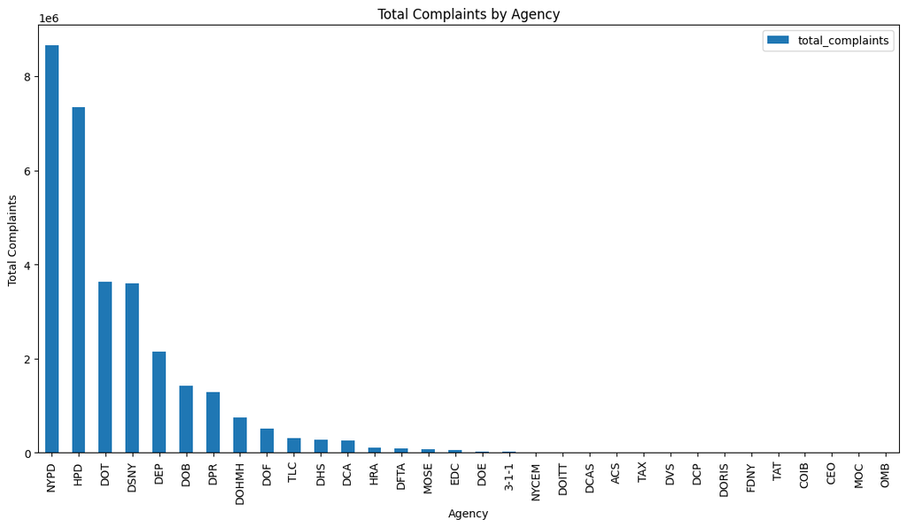

```python
# 2b)
# Create an in-memory SQLite database connection
conn = connect(':memory:')

# Write the DataFrame df2 to an SQL table named 'df2'
df2.to_sql('df2', conn)

# SQL query to sort agencies by total number of complaints
query = '''

    SELECT
        agency,
        SUM(num_complaints) AS total_complaints
    FROM
        df2
    GROUP BY
        agency
    ORDER BY
        total_complaints DESC
'''

# Execute the SQL query and retrieve the results as a DataFrame
sorted_agencies = pd.read_sql_query(query, conn)

# fix a broken agency name
lst = list(sorted_agencies["agency"])
lst[14] = "MOSE"
sorted_agencies["agency"] = lst

# Plot the sorted agencies and their number of complaints
sorted_agencies.plot(kind = "bar", x='agency', y='total_complaints',
                     xlabel = 'Agency', ylabel = 'Total Complaints',
                     title = 'Total Complaints by Agency')

sorted_agencies.set_index("agency", inplace=True)
sorted_agencies.T
```

This query analyzes the data in df2 by agency and calculates the total number of complaints for each agency. The results are presented in descending order of the total complaint count.

Then, we use a bar plot to show the results easly.

```python
# 2c)
# Define the SQL query to find Coronavirus-related complaints
query = '''

    SELECT *
    FROM df2
    WHERE complaint_type LIKE '%Covid%'

'''
# Execute the SQL query and retrieve the results as a DataFrame
coronavirus_complaints = pd.read_sql_query(query, conn)

# Show the appropriate rows containing Coronavirus-related complaints
coronavirus_complaints = pd.DataFrame(coronavirus_complaints).drop("index", axis = "columns")
coronavirus_complaints
```

|  | year | agency | complaint_type | num_complaints |
| --- | --- | --- | --- | --- |
| 0 | 2020 | DOB | COVID-19 Non-essential Construction | 6643 |
| 1 | 2021 | DOB | COVID-19 Non-essential Construction | 678 |
| 2 | 2022 | DOB | COVID-19 Non-essential Construction | 1 |

This query fetches all the data from the df2 table, but only includes rows where the complaint type mentions or includes the word "Covid".

We can see how the covid complaints decreased fast from 2020 to 2021 (arrival of vaccines) and in 2022 droped to a single compaint which shows how the pandemic comes to an end.

```python
# 3a)
# Define the SQL query to find noise complaints
query = '''

        WITH noise_complaints AS (
          SELECT year, agency, complaint_type, num_complaints,
                SUM(num_complaints) OVER (PARTITION BY year, agency) AS total_complaints
          FROM df2
          WHERE complaint_type LIKE '%Noise%'
        )
        SELECT *
        FROM noise_complaints
        WHERE total_complaints < 10000
        ORDER BY total_complaints DESC
        LIMIT 5
'''

# Execute the SQL query and retrieve the results as a DataFrame
Noise_complaints = pd.read_sql_query(query, conn)

# Top 5 rows ordered by total_complaints
Noise_complaints = pd.DataFrame(Noise_complaints)
Noise_complaints
```

|  | year | agency | complaint_type | num_complaints | total_complaints |
| --- | --- | --- | --- | --- | --- |
| 0 | 2012 | 3-1-1 | Noise Survey | 8801 | 8801 |
| 1 | 2011 | 3-1-1 | Noise Survey | 7500 | 7500 |
| 2 | 2019 | EDC | Noise - Helicopter | 3332 | 3332 |
| 3 | 2015 | EDC | Noise - Helicopter | 1505 | 1505 |
| 4 | 2014 | EDC | Noise - Helicopter | 1289 | 1289 |

This query extracts noise-related complaints from the df2 table and calculates the total number of complaints for each year and agency.

Then, filters the results to include only noise-related complaints where the total number of complaints for the corresponding year and agency is less than 10,000. Theresults are sorted in descending order of total complaints and limited to the top 5 rows.

```python
# 3b)
query = '''

      WITH ranked_complaints AS (
          SELECT year, agency, complaint_type, num_complaints,
                ROW_NUMBER() OVER (PARTITION BY year ORDER BY num_complaints DESC) AS row_num
          FROM df2
      )
      SELECT year, agency, complaint_type, num_complaints
      FROM ranked_complaints
      WHERE row_num <= 5
      ORDER BY year DESC, num_complaints DESC;

'''

# Execute the SQL query and retrieve the results as a DataFrame
complaints = pd.read_sql_query(query, conn)
complaints
```

|  | year | agency | complaint_type | num_complaints |
| --- | --- | --- | --- | --- |
| 0 | 2022 | NYPD | Illegal Parking | 228949 |
| 1 | 2022 | NYPD | Noise - Residential | 224350 |
| 2 | 2022 | HPD | HEAT/HOT WATER | 145078 |
| 3 | 2022 | NYPD | Noise - Street/Sidewalk | 88398 |
| 4 | 2022 | NYPD | Blocked Driveway | 88147 |
| ... | ... | ... | ... | ... |
| 60 | 2010 | HPD | HEATING | 214218 |
| 61 | 2010 | HPD | GENERAL CONSTRUCTION | 127118 |
| 62 | 2010 | DOT | Street Light Condition | 116466 |
| 63 | 2010 | NYPD | Noise - Residential | 115632 |
| 64 | 2010 | HPD | PLUMBING | 111504 |

65 rows × 4 columns

This query ranks the complaints in the df2 table based on the number of complaints for each year and selects the top 5 complaints for each year. The result is sorted by year and the number of complaints.

5 rows for each year representing the top 5 complaints for each year.

**Plot our results**

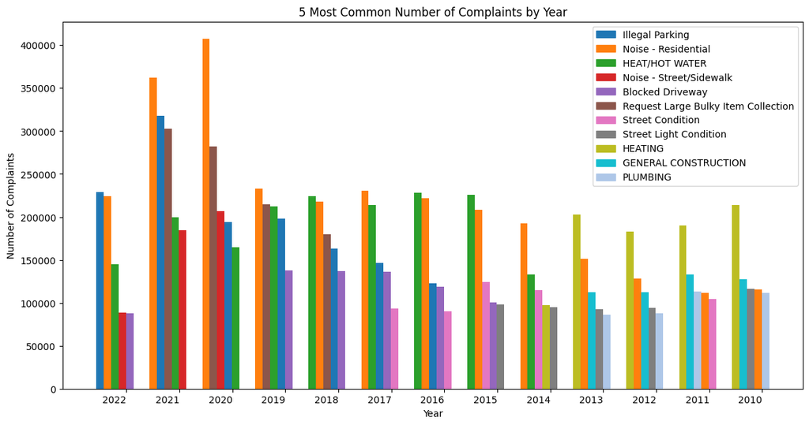

```python
# Create a figure and axis
fig, ax = plt.subplots()

# Set the width for each bar
bar_width = 0.7

# Define the colors for the bars
colors = ['#1f77b4', '#ff7f0e', '#2ca02c', '#d62728', '#9467bd', '#8c564b', '#e377c2', '#7f7f7f', '#bcbd22', '#17becf', '#aec7e8']
# Dictionary to track complaint types and assigned colors
complaint_colors = {}

# Iterate over each year
for i, year in enumerate(complaints['year'].unique()):
    # Get the data for the current year
    year_data = complaints[complaints['year'] == year]

    # Calculate the x-axis positions for the bars
    x = [i * 5 + j * bar_width for j in range(5)]

    # Plot the bars for the current year
    for j, complaint_type in enumerate(year_data['complaint_type'].unique()):
        complaint_type_data = year_data[year_data['complaint_type'] == complaint_type]

        # Check if the complaint type has been assigned a color before
        if complaint_type in complaint_colors:
            color = complaint_colors[complaint_type]
        else:
            # Assign a color to the complaint type
            color = colors[len(complaint_colors) % len(colors)]
            complaint_colors[complaint_type] = color

        ax.bar(x[j], complaint_type_data['num_complaints'], width=bar_width, color=color)

# Set the x-axis labels
x_ticks = [i * 5 + 2.5 for i in range(len(complaints['year'].unique()))]
ax.set_xticks(x_ticks)
ax.set_xticklabels(complaints['year'].unique(), ha='right')

# Set the y-axis label
ax.set_ylabel('Number of Complaints')
ax.set_xlabel('Year')
# Set the title
ax.set_title('5 Most Common Number of Complaints by Year')

# Create custom legend
legend_elements = [plt.Rectangle((0, 0), 1, 1, color=complaint_colors[complaint_type], label=complaint_type) for complaint_type in complaint_colors]
ax.legend(handles=legend_elements)

# Show the plot
plt.show()
```

Each year have 5 bars with the top 5 complaint types we found before.

We can see ths "Noise - residential" is repeated through all the years.

"illegal parking" for example is a common top 5 since 2016 but not before.

```python
# 4a)
# Read zips dataset into pandas dataframe and display results

# Add the DataFrame as an SQL table
zip_df = pd.read_csv('/content/drive/MyDrive/population_by_zip_2010.csv')
table_exists = pd.io.sql.table_exists('zip_df', conn)
if not table_exists:
    zip_df.to_sql('zip_df', conn)

# Display the first 5 rows of the SQL table
sql_query = 'SELECT * FROM zip_df LIMIT 2000'
result = pd.read_sql(sql_query, conn)
result = result.drop("index", axis = "columns")
result.head(5)
```

|  | population | minimum_age | maximum_age | gender | zipcode | geo_id |
| --- | --- | --- | --- | --- | --- | --- |
| 0 | 50 | 30.0 | 34.0 | female | 61747 | 8600000US61747 |
| 1 | 5 | 85.0 | NaN | male | 64120 | 8600000US64120 |
| 2 | 1389 | 30.0 | 34.0 | male | 95117 | 8600000US95117 |
| 3 | 231 | 60.0 | 61.0 | female | 74074 | 8600000US74074 |
| 4 | 56 | 0.0 | 4.0 | female | 58042 | 8600000US58042 |

Then, we wrote a query that retrieves all columns and rows from the table called zip_df and limits the output to the first 2000 rows.

```python
# 4b)
# Run SQL query and display results

query = '''
SELECT
    incident_zip AS zipcode,
    COUNT(*) AS total_complaints,
    SUM(IF(
        EXTRACT(DAYOFWEEK FROM created_date) = 7 AND
        EXTRACT(DAYOFWEEK FROM closed_date) = 2 AND
        TIMESTAMP_TRUNC(closed_date, DAY) <= TIMESTAMP_TRUNC(TIMESTAMP_ADD(created_date, INTERVAL 1 DAY), DAY),
        1,
        0
    )) AS closed_in_1_day,
    COUNT(*) - SUM(IF(
        EXTRACT(DAYOFWEEK FROM created_date) = 7 AND
        EXTRACT(DAYOFWEEK FROM closed_date) = 2 AND
        TIMESTAMP_TRUNC(closed_date, DAY) <= TIMESTAMP_TRUNC(TIMESTAMP_ADD(created_date, INTERVAL 1 DAY), DAY),
        1,
        0
    )) AS closed_in_more_than_1_day
FROM
    `bigquery-public-data.new_york.311_service_requests`
WHERE
    incident_zip IS NOT NULL
GROUP BY
    zipcode
ORDER BY
    total_complaints DESC

'''

df3 = client.query(query).to_dataframe()
df3.head(5)
```

[output not shown]

This query analyzes service requests data and provides information on the number of complaints, the number of complaints closed within 1 day, and the number of complaints closed in more than 1 day, grouped by zip code. The results are ordered by the total number of complaints in descending order.

```python
# 4c)

# Create the df3 table
df3.to_sql('df3', conn, if_exists='replace', index=False)

# Execute the query to find the zip code with the highest ratio of complaints per population (closed within 1 business day)
query = '''

        SELECT
            z.zipcode, SUM(z.population) AS total_population,
            t.closed_in_1_day, t.total_complaints,
            (t.closed_in_1_day / SUM(z.population)) AS complaints_population_ratio
        FROM
            zip_df z
        JOIN
            df3 t ON z.zipcode = t.zipcode
        WHERE
             t.closed_in_1_day IS NOT NULL
        GROUP BY
             z.zipcode
        ORDER BY
              complaints_population_ratio DESC
        LIMIT 1;

'''

print("Zip Code with the highest ratio of complaints per population (closed within 1 business day):")
print("-" * 100)
df1 = pd.read_sql_query(query, conn)
df1
```

```
Zip Code with the highest ratio of complaints per population (closed within 1 business day):
----------------------------------------------------------------------------------------------------
```

|  | zipcode | total_population | closed_in_1_day | total_complaints | complaints_population_ratio |
| --- | --- | --- | --- | --- | --- |
| 0 | 10173 | 6 | 152 | 181 | 25 |

This query combines information from two tables to find the zip code with the highest ratio of complaints closed within 1 day to the total population. It calculates the total population for each zip code, joins it with complaint data, and calculates the complaints-to-population ratio. The result is sorted based on this ratio, and the output is limited to the zip code with the highest ratio.

```python
# Execute the query for complaints closed in more than 1 day
query = '''
        SELECT
            z.zipcode, SUM(z.population) AS total_population,
            t.closed_in_more_than_1_day, t.total_complaints,
            (t.closed_in_more_than_1_day / SUM(z.population)) AS complaints_population_ratio
        FROM
            zip_df z
        JOIN
            df3 t ON z.zipcode = t.zipcode
        WHERE
            t.closed_in_more_than_1_day IS NOT NULL
        GROUP BY
             z.zipcode
        ORDER BY
             complaints_population_ratio DESC
        LIMIT 1;
'''
print("\nZip Code with the highest ratio of complaints per population (closed in more than 1 day):")
print("-" * 100)
df2 = pd.read_sql_query(query, conn)
df2
```

```
Zip Code with the highest ratio of complaints per population (closed in more than 1 day):
----------------------------------------------------------------------------------------------------
```

|  | zipcode | total_population | closed_in_more_than_1_day | total_complaints | complaints_population_ratio |
| --- | --- | --- | --- | --- | --- |
| 0 | 10103 | 9 | 169 | 393 | 18 |

This query uses the same way to find the zip code with the highest ratio of complaints closed in more than 1 day to the total population.